# matplotlib.artist.Artist.set

**Artist.set(*, *agg_filter=<UNSET>*, *alpha=<UNSET>*, *animated=<UNSET>*, *clip_box=<UNSET>*, *clip_on=<UNSET>*, *clip_path=<UNSET>*, *gid=<UNSET>*, *in_layout=<UNSET>*, *label=<UNSET>*, *mouseover=<UNSET>*, *path_effects=<UNSET>*, *picker=<UNSET>*, *rasterized=<UNSET>*, *sketch_params=<UNSET>*, *snap=<UNSET>*, *transform=<UNSET>*, *url=<UNSET>*, *visible=<UNSET>*, *zorder=<UNSET>*)[[source]](https://github.com/matplotlib/matplotlib/blob/v3.9.2/lib/matplotlib/artist.py#L1220-L1224)**

Set multiple properties at once.

Supported properties are

| Property | Description |
| --- | --- |
| `agg_filter` | a filter function, which takes a (m, n, 3) float array and a dpi value, and returns a (m, n, 3) array and two offsets from the bottom left corner of the image |
| `alpha` | scalar or None |
| `animated` | bool |
| `clip_box` | `BboxBase` or None |
| `clip_on` | bool |
| `clip_path` | Patch or (Path, Transform) or None |
| `figure` | `Figure` |
| `gid` | str |
| `in_layout` | bool |
| `label` | object |
| `mouseover` | bool |
| `path_effects` | list of `AbstractPathEffect` |
| `picker` | None or bool or float or callable |
| `rasterized` | bool |
| `sketch_params` | (scale: float, length: float, randomness: float) |
| `snap` | bool or None |
| `transform` | `Transform` |
| `url` | str |
| `visible` | bool |
| `zorder` | float |

## Examples using `matplotlib.artist.Artist.set`

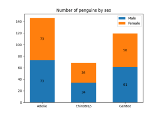

[Bar Label Demo](https://matplotlib.org/stable/gallery/lines_bars_and_markers/bar_label_demo.html#sphx-glr-gallery-lines-bars-and-markers-bar-label-demo-py)

Bar Label Demo

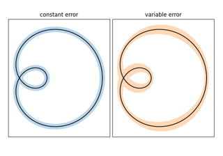

[Curve with error band](https://matplotlib.org/stable/gallery/lines_bars_and_markers/curve_error_band.html#sphx-glr-gallery-lines-bars-and-markers-curve-error-band-py)

Curve with error band

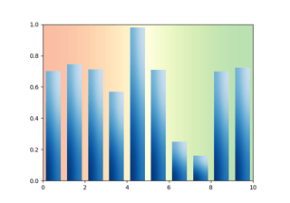

[Bar chart with gradients](https://matplotlib.org/stable/gallery/lines_bars_and_markers/gradient_bar.html#sphx-glr-gallery-lines-bars-and-markers-gradient-bar-py)

Bar chart with gradients

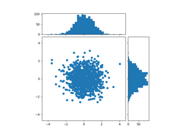

[Scatter plot with histograms](https://matplotlib.org/stable/gallery/lines_bars_and_markers/scatter_hist.html#sphx-glr-gallery-lines-bars-and-markers-scatter-hist-py)

Scatter plot with histograms

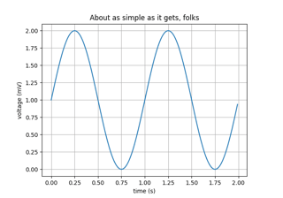

[Simple Plot](https://matplotlib.org/stable/gallery/lines_bars_and_markers/simple_plot.html#sphx-glr-gallery-lines-bars-and-markers-simple-plot-py)

Simple Plot

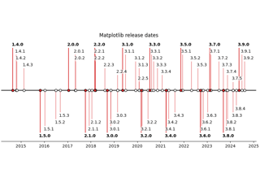

[Creating a timeline with lines, dates, and text](https://matplotlib.org/stable/gallery/lines_bars_and_markers/timeline.html#sphx-glr-gallery-lines-bars-and-markers-timeline-py)

Creating a timeline with lines, dates, and text

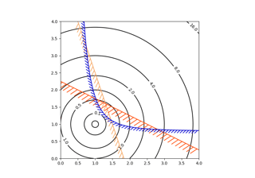

[Contouring the solution space of optimizations](https://matplotlib.org/stable/gallery/images_contours_and_fields/contours_in_optimization_demo.html#sphx-glr-gallery-images-contours-and-fields-contours-in-optimization-demo-py)

Contouring the solution space of optimizations

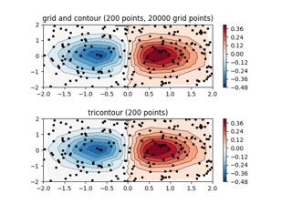

[Contour plot of irregularly spaced data](https://matplotlib.org/stable/gallery/images_contours_and_fields/irregulardatagrid.html#sphx-glr-gallery-images-contours-and-fields-irregulardatagrid-py)

Contour plot of irregularly spaced data

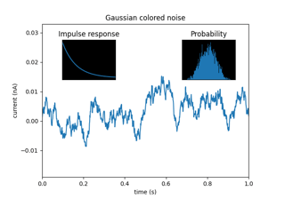

[Axes Demo](https://matplotlib.org/stable/gallery/subplots_axes_and_figures/axes_demo.html#sphx-glr-gallery-subplots-axes-and-figures-axes-demo-py)

Axes Demo

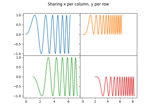

[Creating multiple subplots using plt.subplots](https://matplotlib.org/stable/gallery/subplots_axes_and_figures/subplots_demo.html#sphx-glr-gallery-subplots-axes-and-figures-subplots-demo-py)

Creating multiple subplots using plt.subplots

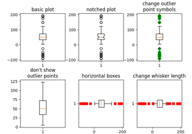

[Boxplots](https://matplotlib.org/stable/gallery/statistics/boxplot_demo.html#sphx-glr-gallery-statistics-boxplot-demo-py)

Boxplots

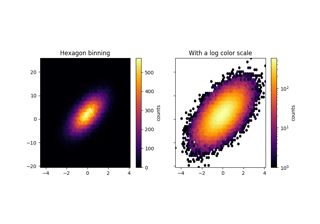

[Hexagonal binned plot](https://matplotlib.org/stable/gallery/statistics/hexbin_demo.html#sphx-glr-gallery-statistics-hexbin-demo-py)

Hexagonal binned plot

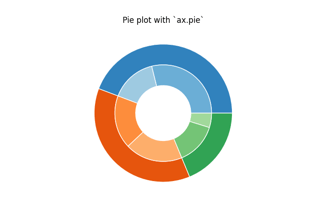

[Nested pie charts](https://matplotlib.org/stable/gallery/pie_and_polar_charts/nested_pie.html#sphx-glr-gallery-pie-and-polar-charts-nested-pie-py)

Nested pie charts

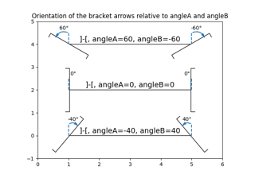

[Angle annotations on bracket arrows](https://matplotlib.org/stable/gallery/text_labels_and_annotations/angles_on_bracket_arrows.html#sphx-glr-gallery-text-labels-and-annotations-angles-on-bracket-arrows-py)

Angle annotations on bracket arrows

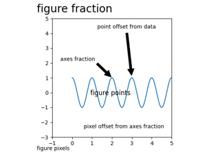

[Annotating Plots](https://matplotlib.org/stable/gallery/text_labels_and_annotations/annotation_demo.html#sphx-glr-gallery-text-labels-and-annotations-annotation-demo-py)

Annotating Plots

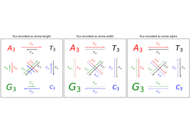

[Arrow Demo](https://matplotlib.org/stable/gallery/text_labels_and_annotations/arrow_demo.html#sphx-glr-gallery-text-labels-and-annotations-arrow-demo-py)

Arrow Demo

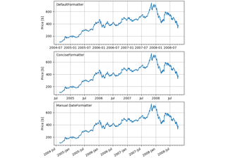

[Date tick labels](https://matplotlib.org/stable/gallery/text_labels_and_annotations/date.html#sphx-glr-gallery-text-labels-and-annotations-date-py)

Date tick labels

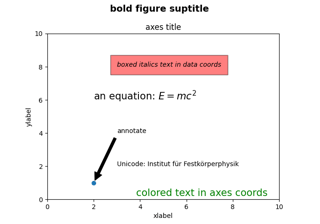

[Text Commands](https://matplotlib.org/stable/gallery/text_labels_and_annotations/text_commands.html#sphx-glr-gallery-text-labels-and-annotations-text-commands-py)

Text Commands

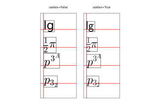

[Usetex Baseline Test](https://matplotlib.org/stable/gallery/text_labels_and_annotations/usetex_baseline_test.html#sphx-glr-gallery-text-labels-and-annotations-usetex-baseline-test-py)

Usetex Baseline Test

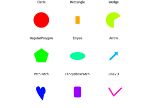

[Reference for Matplotlib artists](https://matplotlib.org/stable/gallery/shapes_and_collections/artist_reference.html#sphx-glr-gallery-shapes-and-collections-artist-reference-py)

Reference for Matplotlib artists

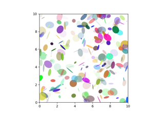

[Ellipse Demo](https://matplotlib.org/stable/gallery/shapes_and_collections/ellipse_demo.html#sphx-glr-gallery-shapes-and-collections-ellipse-demo-py)

Ellipse Demo

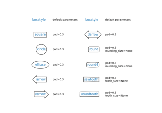

[Drawing fancy boxes](https://matplotlib.org/stable/gallery/shapes_and_collections/fancybox_demo.html#sphx-glr-gallery-shapes-and-collections-fancybox-demo-py)

Drawing fancy boxes

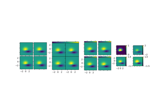

[Demo Axes Grid](https://matplotlib.org/stable/gallery/axes_grid1/demo_axes_grid.html#sphx-glr-gallery-axes-grid1-demo-axes-grid-py)

Demo Axes Grid

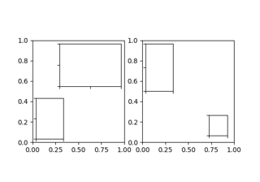

[Inset locator demo](https://matplotlib.org/stable/gallery/axes_grid1/inset_locator_demo.html#sphx-glr-gallery-axes-grid1-inset-locator-demo-py)

Inset locator demo

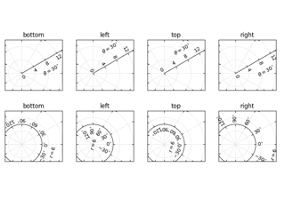

[axis_direction demo](https://matplotlib.org/stable/gallery/axisartist/demo_axis_direction.html#sphx-glr-gallery-axisartist-demo-axis-direction-py)

axis_direction demo

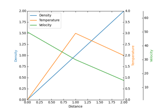

[Parasite Axes demo](https://matplotlib.org/stable/gallery/axisartist/demo_parasite_axes.html#sphx-glr-gallery-axisartist-demo-parasite-axes-py)

Parasite Axes demo

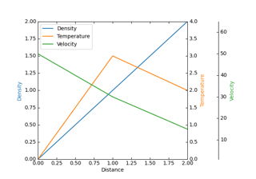

[Parasite axis demo](https://matplotlib.org/stable/gallery/axisartist/demo_parasite_axes2.html#sphx-glr-gallery-axisartist-demo-parasite-axes2-py)

Parasite axis demo

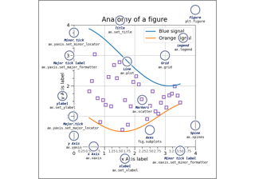

[Anatomy of a figure](https://matplotlib.org/stable/gallery/showcase/anatomy.html#sphx-glr-gallery-showcase-anatomy-py)

Anatomy of a figure

[figure not shown]

[Animated 3D random walk](https://matplotlib.org/stable/gallery/animation/random_walk.html#sphx-glr-gallery-animation-random-walk-py)

Animated 3D random walk

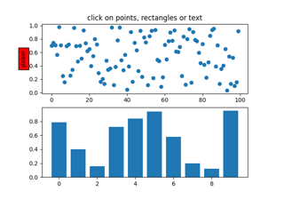

[Pick event demo](https://matplotlib.org/stable/gallery/event_handling/pick_event_demo.html#sphx-glr-gallery-event-handling-pick-event-demo-py)

Pick event demo

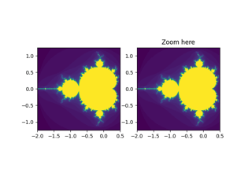

[Viewlims](https://matplotlib.org/stable/gallery/event_handling/viewlims.html#sphx-glr-gallery-event-handling-viewlims-py)

Viewlims

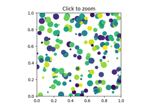

[Zoom Window](https://matplotlib.org/stable/gallery/event_handling/zoom_window.html#sphx-glr-gallery-event-handling-zoom-window-py)

Zoom Window

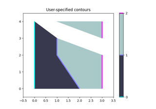

[Manual Contour](https://matplotlib.org/stable/gallery/misc/contour_manual.html#sphx-glr-gallery-misc-contour-manual-py)

Manual Contour

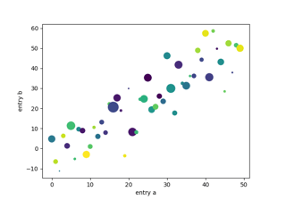

[Plotting with keywords](https://matplotlib.org/stable/gallery/misc/keyword_plotting.html#sphx-glr-gallery-misc-keyword-plotting-py)

Plotting with keywords

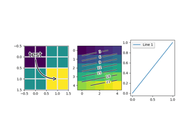

[Patheffect Demo](https://matplotlib.org/stable/gallery/misc/patheffect_demo.html#sphx-glr-gallery-misc-patheffect-demo-py)

Patheffect Demo

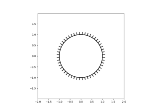

[TickedStroke patheffect](https://matplotlib.org/stable/gallery/misc/tickedstroke_demo.html#sphx-glr-gallery-misc-tickedstroke-demo-py)

TickedStroke patheffect

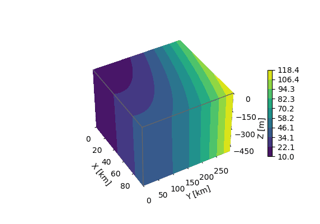

[3D box surface plot](https://matplotlib.org/stable/gallery/mplot3d/box3d.html#sphx-glr-gallery-mplot3d-box3d-py)

3D box surface plot

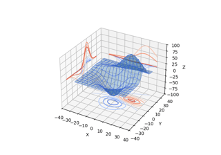

[Project contour profiles onto a graph](https://matplotlib.org/stable/gallery/mplot3d/contour3d_3.html#sphx-glr-gallery-mplot3d-contour3d-3-py)

Project contour profiles onto a graph

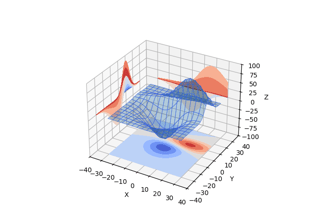

[Project filled contour onto a graph](https://matplotlib.org/stable/gallery/mplot3d/contourf3d_2.html#sphx-glr-gallery-mplot3d-contourf3d-2-py)

Project filled contour onto a graph

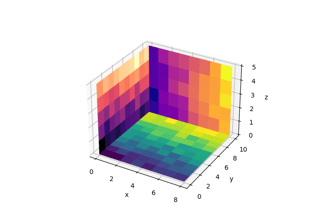

[2D images in 3D](https://matplotlib.org/stable/gallery/mplot3d/imshow3d.html#sphx-glr-gallery-mplot3d-imshow3d-py)

2D images in 3D

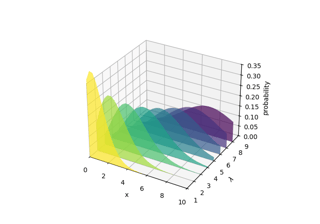

[Generate polygons to fill under 3D line graph](https://matplotlib.org/stable/gallery/mplot3d/polys3d.html#sphx-glr-gallery-mplot3d-polys3d-py)

Generate polygons to fill under 3D line graph

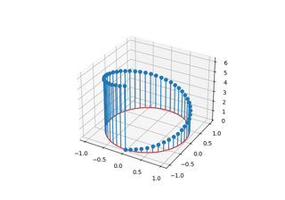

[3D stem](https://matplotlib.org/stable/gallery/mplot3d/stem3d_demo.html#sphx-glr-gallery-mplot3d-stem3d-demo-py)

3D stem

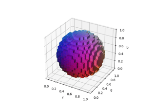

[3D voxel / volumetric plot with RGB colors](https://matplotlib.org/stable/gallery/mplot3d/voxels_rgb.html#sphx-glr-gallery-mplot3d-voxels-rgb-py)

3D voxel / volumetric plot with RGB colors

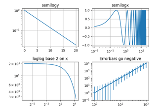

[Log Demo](https://matplotlib.org/stable/gallery/scales/log_demo.html#sphx-glr-gallery-scales-log-demo-py)

Log Demo

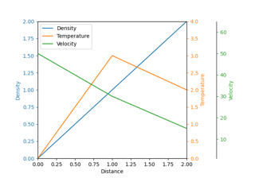

[Multiple y-axis with Spines](https://matplotlib.org/stable/gallery/spines/multiple_yaxis_with_spines.html#sphx-glr-gallery-spines-multiple-yaxis-with-spines-py)

Multiple y-axis with Spines

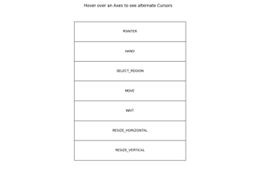

[Mouse Cursor](https://matplotlib.org/stable/gallery/widgets/mouse_cursor.html#sphx-glr-gallery-widgets-mouse-cursor-py)

Mouse Cursor

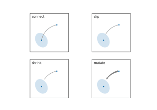

[Annotate Explain](https://matplotlib.org/stable/gallery/userdemo/annotate_explain.html#sphx-glr-gallery-userdemo-annotate-explain-py)

Annotate Explain

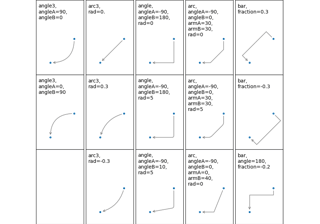

[Connection styles for annotations](https://matplotlib.org/stable/gallery/userdemo/connectionstyle_demo.html#sphx-glr-gallery-userdemo-connectionstyle-demo-py)

Connection styles for annotations

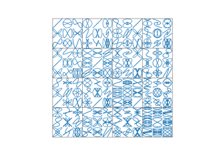

[Nested GridSpecs](https://matplotlib.org/stable/gallery/userdemo/demo_gridspec06.html#sphx-glr-gallery-userdemo-demo-gridspec06-py)

Nested GridSpecs

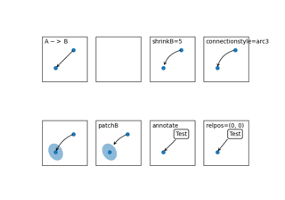

[Simple Annotate01](https://matplotlib.org/stable/gallery/userdemo/simple_annotate01.html#sphx-glr-gallery-userdemo-simple-annotate01-py)

Simple Annotate01

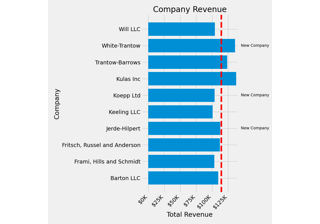

[The Lifecycle of a Plot](https://matplotlib.org/stable/tutorials/lifecycle.html#sphx-glr-tutorials-lifecycle-py)

The Lifecycle of a Plot

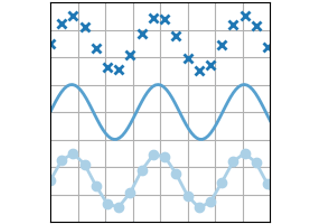

[plot(x, y)](https://matplotlib.org/stable/plot_types/basic/plot.html#sphx-glr-plot-types-basic-plot-py)

plot(x, y)

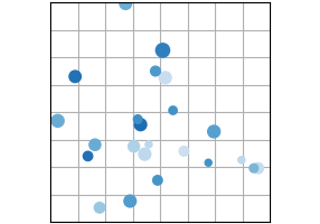

[scatter(x, y)](https://matplotlib.org/stable/plot_types/basic/scatter_plot.html#sphx-glr-plot-types-basic-scatter-plot-py)

scatter(x, y)

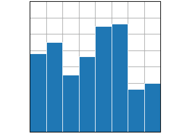

[bar(x, height)](https://matplotlib.org/stable/plot_types/basic/bar.html#sphx-glr-plot-types-basic-bar-py)

bar(x, height)

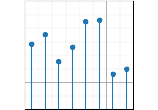

[stem(x, y)](https://matplotlib.org/stable/plot_types/basic/stem.html#sphx-glr-plot-types-basic-stem-py)

stem(x, y)

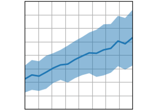

[fill_between(x, y1, y2)](https://matplotlib.org/stable/plot_types/basic/fill_between.html#sphx-glr-plot-types-basic-fill-between-py)

fill_between(x, y1, y2)

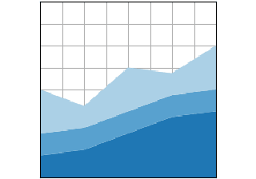

[stackplot(x, y)](https://matplotlib.org/stable/plot_types/basic/stackplot.html#sphx-glr-plot-types-basic-stackplot-py)

stackplot(x, y)

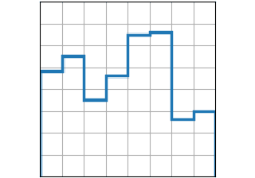

[stairs(values)](https://matplotlib.org/stable/plot_types/basic/stairs.html#sphx-glr-plot-types-basic-stairs-py)

stairs(values)

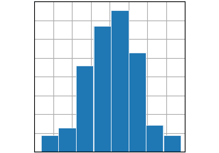

[hist(x)](https://matplotlib.org/stable/plot_types/stats/hist_plot.html#sphx-glr-plot-types-stats-hist-plot-py)

hist(x)

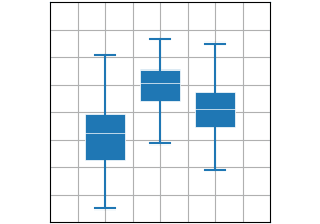

[boxplot(X)](https://matplotlib.org/stable/plot_types/stats/boxplot_plot.html#sphx-glr-plot-types-stats-boxplot-plot-py)